# ggplot_homework

# Homework Info

## Learning Objectives

- Practice making plots with ggplot2
- Create your own theme and use it with plots

## Background

QikBit is a start-up company producing low cost fitness trackers. Their flagship product, the KwikBit Unit1 (spot the mistake on the patent form) reproduces the functionality of the best-in-class commercial fitness trackers, but is cheap to make. They are currently preparing to pitch to a potential investor and require a selection of charts to include in their presentation and promotional materials.

## Data

The data for this assignment is provided in the CodeClanData package.

- qb_revenue_breakdown
- qb_monthly_sales # pivot wide
- qb_competitors
- qb_device_data

Take a little time before you start to familiarise yourself with the data.

# MVP

## Part 1

```r
library(tidyverse)
library(janitor)
library(CodeClanData)
library(lubridate)
```

```r
revenue_breakdown <- clean_names(qb_revenue_breakdown)

monthly_sales <- clean_names(qb_monthly_sales)

competitors <- clean_names(qb_competitors)

device_data <- clean_names(qb_device_data)
```

### Question 1.

Take the data in the dataset qb_revenue_breakdown and make a stacked bar chart showing the sources of revenue across the two years in the dataset.

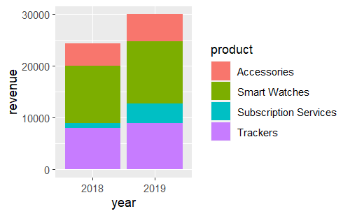

```r
ggplot(revenue_breakdown) +
  geom_col(aes(x = year, y = revenue, fill = product)) #, position = "dodge")
```

### Question 2.

Make a line chart showing monthly sales of the “flagship product” - the ‘KwikBit Unit 1’ - over the last year. This data is inside qb_monthly_sales, but you will need to use filter() or subset() (base R).

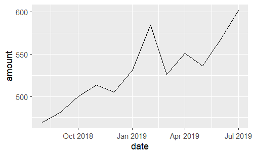

```r
ggplot(monthly_sales) +
  geom_line(
    aes(x = date, y = amount),
    data = subset(monthly_sales, cashflow ==  "Kwikbit Unit 1 Sales"))
```

### Question 3.

Make a line chart showing monthly revenue and costs over the last year. This data is also in qb_monthly_sales.

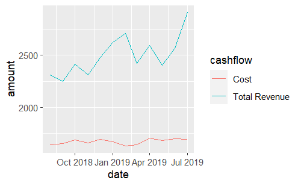

```r
ggplot(monthly_sales) +
  aes(x = date, y = amount, colour = cashflow) +
  geom_line(
    data = subset(monthly_sales, cashflow ==  "Total Revenue")) +
  geom_line(
    data = subset(monthly_sales, cashflow ==  "Cost"))
```

### Question 4.

Show annual sales of personal fitness trackers over the last 5 years broken down by company as a ribbon plot (use geom_area). This data is in qb_competitors.

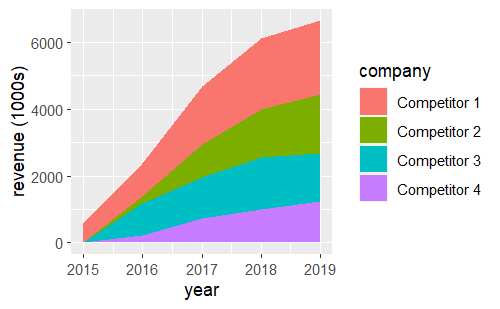

```r
competitors %>%
  mutate(revenue_thousands = revenue/1000) %>%

ggplot() +
  geom_area(
    aes(x = year, y = revenue_thousands, group = company, fill = company)) +
  ylab ("revenue (1000s)")
```

### Question 5.

Now show the sales from the four competitors as a line graph. Include an extra layer that shows the data points used to make the lines.

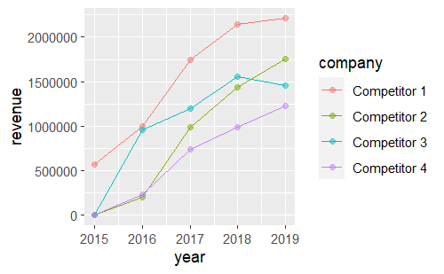

```r
ggplot(competitors) +
  aes(x = year, y = revenue, colour = company) +
  geom_line(aes(group = company), alpha = 1) +
  geom_point(alpha = 0.5)
```

### Question 6.

Now the company wants to compare the number of steps that their device counts vs. their competitors. Make a line graph of the number of steps throughout time, and use faceting to compare between companies and people. The data for this is in qb_device_data.

```r
device_data_update <- device_data %>%
  mutate(time_text = str_c(hours, ":", mins), time_date = hm(time_text))
```

```r
device_data_update <- device_data %>%
  mutate(device_data, decimal_hour = hours + (mins/60))
```

[figure not shown]

```r
ggplot(device_data_update) +
  aes(x = time_date, y = counts, group = id, colour = device) +
  geom_line() +
  facet_wrap(~ device)
```

## Part 2

Take the plots that you produced in part one and now polish them by:

*1 Adding appropriate labels* 2 Changing the scales and coordinate when appropriate. *3 Applying a unified theme, which is described below:* Graphs should have white backgrounds, and use colour sparingly. * There should be faint grid lines. * Font sizes should be ~12pt although titles should be slightly larger and axis labels can be slightly smaller. * All plots should use colours from the following company colour scheme.

```r
col_scheme <- c("#E89FE9", "#50434F", "#B6A7B5", "#F9A472", "#BD7040")
```

```r
unified_theme <- function() {
  font <- "Georgia"   #assign font family up front

  theme_light() %+replace%    #replace elements we want to change

  theme(
    # add border
    panel.border = element_rect(colour = "#50434F", fill = NA, linetype = 2),

    # colour background
    panel.background = element_rect(fill = "white"),

    # modify grid
    panel.grid.major.x = element_line(colour = "#B6A7B5",
                                      linetype = 3, size = 0.5),
    panel.grid.minor.x = element_blank(),
    panel.grid.major.y =  element_line(colour = "#B6A7B5",
                                       linetype = 3, size = 0.5),
    panel.grid.minor.y = element_blank(),

    # modify text, axis and colour
    axis.text = element_text(colour = "#50434F", size = rel(0.9)),
    axis.title = element_text(colour = "#50434F"),
    axis.ticks = element_line(colour = "#50434F"),

    # modify titles and subtitles
    plot.title = element_text(colour = "#50434F",
                              family = "Arial", size = rel(1.5)),
    plot.subtitle = element_text(colour = "#50434F",
                                 family = "Arial", size = rel(1.2))
  )
}
```

# Extension

Try out different ways of plotting these three datasets. Which graphs do you think are particularly effective at showing QikBit’s success?